# BST 222 Project

Zachary Clement

11/18/2021

First, we will consider a model with true beta coefficients that are mostly zero.

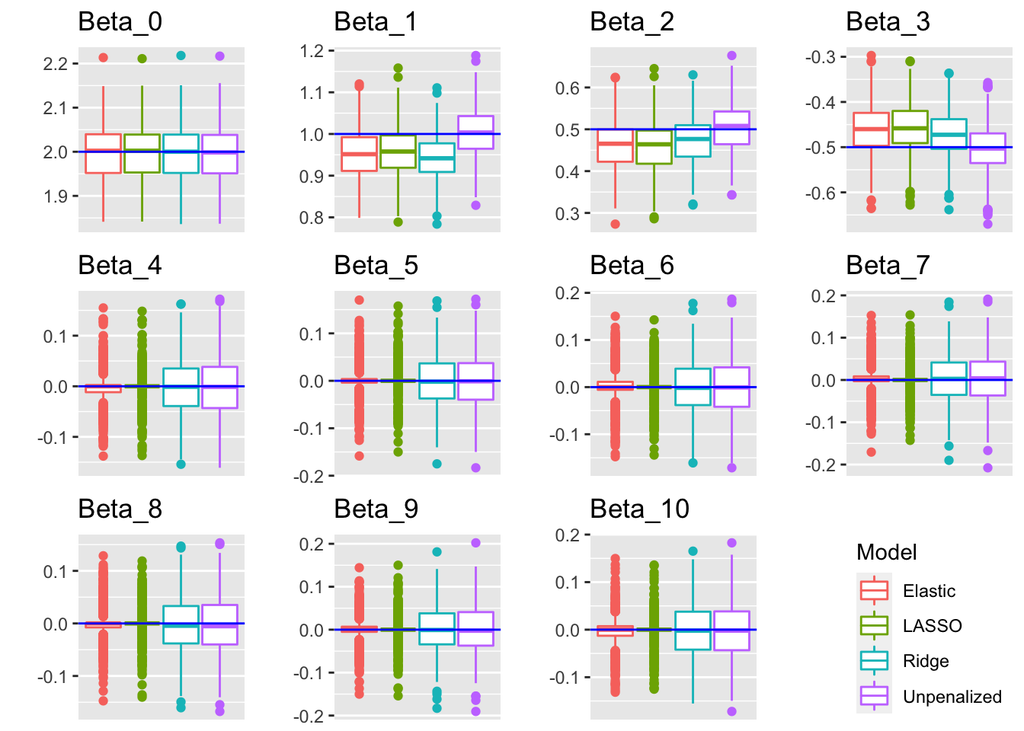

```r
##This is where you change parameters

n_reps <- 500
beta_list <- c(2,  1, .5, -.5, 0, 0, 0, 0, 0, 0, 0)
num_obs <- 300


##These lines may cause errors on your machine, see below if they don't work
future::plan(multisession, workers = parallel::detectCores())
df <- future.apply::future_replicate(n_reps, model_fit(beta_list, num_obs)) %>% t() %>% data.frame()
future::plan(sequential) #I think this should reset your R session because we don't need to parallel process anything else

#The commented line below will do the same thing as the above two lines, but slower.
# df <- replicate(n_reps, model_fit(beta_list, num_obs)) %>% t() %>% data.frame()


plot_all_beta(df, beta_list)
```

We can see from the boxplots of the beta coefficients that LASSO, Ridge, and elastic net tend to underestimate the true parameter, while the unpenalized model is unbiased. However, when parameters are zero, the spread of elastic net and LASSO estimates is much smaller.

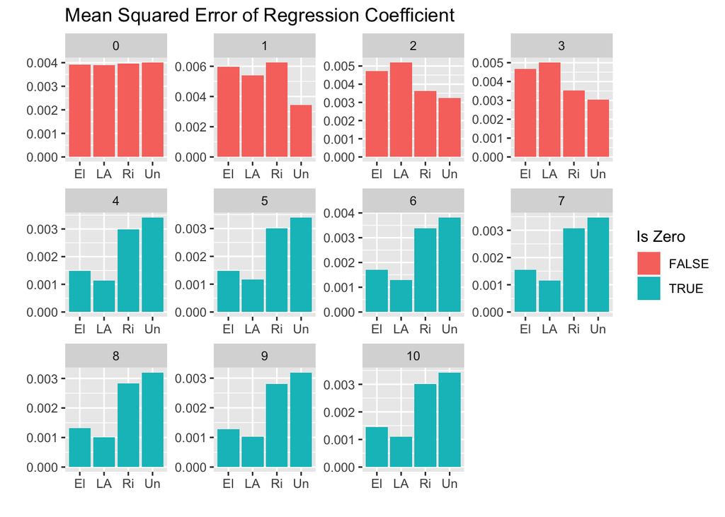

When evaluating the mean squared error of our estimates of regression coefficients, Elastic Net and LASSO regression tend to have lower MSE for coefficients when they are equal to zero.

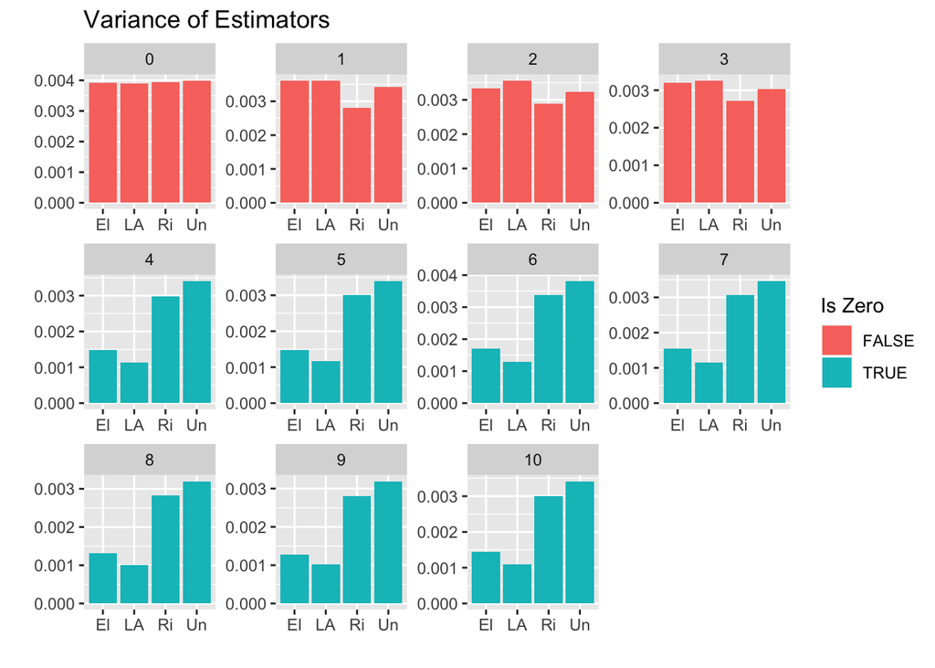

```r
beta_vars %>% tidyr::pivot_longer(cols = colnames(beta_mse)[-1], names_to = "beta_num",
                     values_to = "value") %>%
  separate(beta_num, into = c("junk", "beta_num")) %>%
  mutate(beta_num = as.numeric(beta_num)) %>%
  mutate(short_model = substr(Model, start = 1, stop = 2)) %>%
  arrange(beta_num) %>%
  mutate(is_zero = (beta_list[beta_num + 1] == 0)) %>%
  ggplot() + geom_col(mapping = aes(x = short_model, y = value, fill = is_zero)) +
  facet_wrap(vars(beta_num), scales = "free") +
  labs(x = '', y = '', title = "Variance of Estimators", fill = "Is Zero")
```

The variance in estimates is also much lower for Elastic Net and LASSO regression for zero coefficients, but is comparable to unpenalized regression for non-zero coefficients.

Here, we will get the out-of-sample MSE for our original example:

```r
source('get_mse.R')
future::plan("multisession")

mse_df <- future.apply::future_replicate(500, get_mse(beta_list, num_obs))

future::plan("sequential")

mse_df <- mse_df |> t() |> as.data.frame()

write.csv(mse_df, file = "original_set_out_sample_mse.csv", row.names = F)

sapply(mse_df, median) |> t() |> kable(caption = "Median Out-of-Sample MSE metrics by penalty")
```

Median Out-of-Sample MSE metrics by penalty

| LASSO | Ridge | Elastic | Unpenalized |
| --- | --- | --- | --- |
| 1.034429 | 1.045096 | 1.036979 | 1.046851 |

Here, we get a visualization of how the parameter estimates change with different lambda values:

```r
rm(full_df)
```

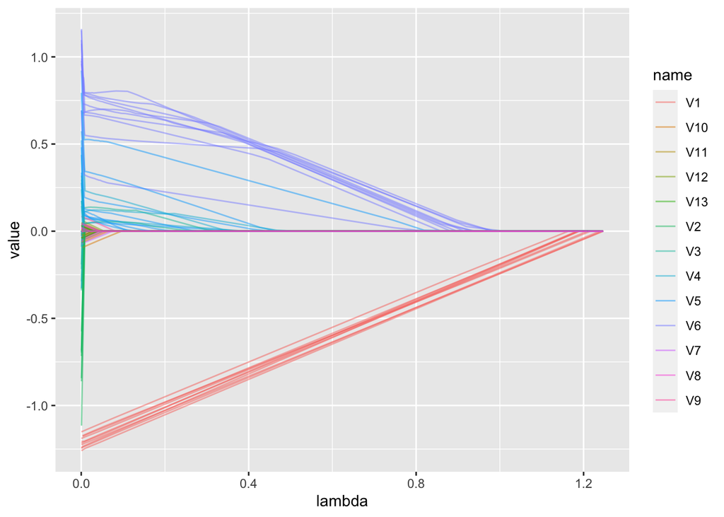

```r
beta_list <- c(2, -1.2, -.7, -.1, .2, .5, 1,0, 0, 0, 0, 0, 0, 0)

for (i in 1:10){

  mat_to_fit <- generate_data(beta_list = beta_list, num_obs = 1000, num_underlying_factors = 1, covariates_per_factor = 4, strength_collinearity = .9)


  current_lasso <- glmnet::glmnet(y = mat_to_fit[,1],
                                  x = mat_to_fit[,2:ncol(mat_to_fit)],
                                  family = "gaussian",
                                  alpha = 1 #1 is lasso penalty (0 is ridge)
                                  )

  current_df <- current_lasso$beta %>%
    t() %>%
    as.matrix() %>%
    data.frame() %>%
    cbind(data.frame(lambda = current_lasso$lambda)) %>%
    pivot_longer(., cols = colnames(.)[colnames(.) != "lambda"])

  current_df$iter = paste(i, current_df$name)

  if (exists("full_df")){
    full_df <- rbind(full_df, current_df)
  }
  else{
    full_df <- current_df
  }
}


  ggplot(data = full_df) +  geom_line(mapping = aes(x = lambda, y = value,group = iter, col = name
                                                     ), alpha = .5)
```

```r
df <- read.csv('aggregate_mse_data.csv')


df2 <- df %>% pivot_longer(cols = c("LASSO", "Ridge", "Elastic", "Unpenalized"),
                           values_to = "MSE",
                           names_to = "Model") %>%
  dplyr::rename(Small = prop_small )

ggplot(df2, mapping = aes(col = Model, x = as.factor(num_obs), y = log(MSE))) +
  geom_boxplot() +
  facet_grid(rows = vars(Small), cols = vars(sparsity), labeller = label_both) +
  labs(x = "Number of Observations")
```

[output not shown]

Other things to test: 1. n > p 2. pairwise correlations are very high